# Linear_regression

# Practical Work 2

```r
setwd("C:/Users/flavi/OneDrive/Documents/ESILV/A4/S1/Machine Learning/Machine_learning/PW1 - Linear Regression")
```

## Multiple Linear Regression

### 1) Load the Boston dataset from MASS package

```r
# load MASS package
library(MASS)

# Check the dimensions of the Boston dataset
dim(Boston)
```

```
## [1] 506  14
```

### 2) Split the dataset into traning set and testing set. (keep all the variables of the Boston data set)

```r
# We use the first 80% observations as the training
train = 1:as.integer(dim(Boston)[1]*0.80)
test = -train

training_data = Boston[train,]
testing_data = Boston[test,]

dim(training_data)
```

```
## [1] 404  14
```

```r
dim(testing_data)
```

```
## [1] 102  14
```

### 3) Check if there is a linear relationship between the variables medv and age. (use cor() function)

We plot age vs medv (response) to have a first guess of the answer (not a proof)

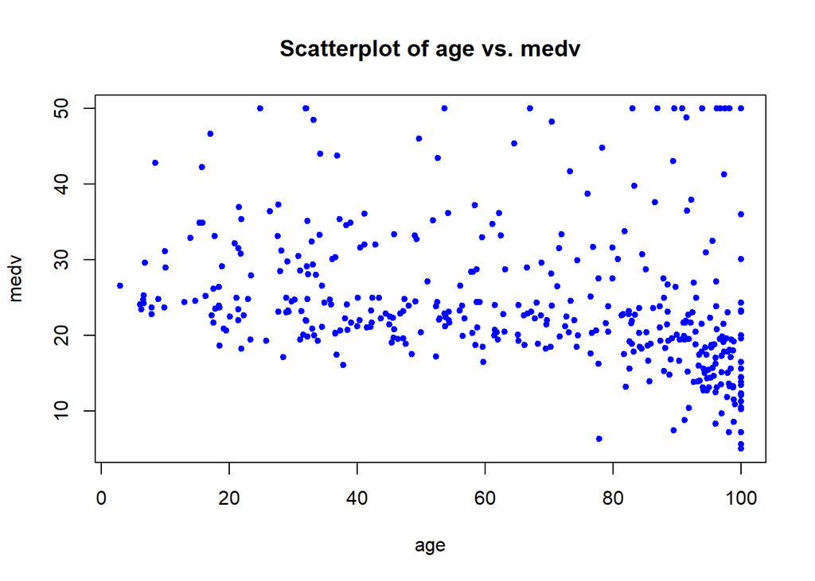

```r
plot(training_data$age, training_data$medv,
     xlab="age", ylab="medv",
     main="Scatterplot of age vs. medv",
     col="blue", type="p",pch = 20)
```

Then, we compute the correlations between age (a predictor) and medv (the response)

```r
# Syntax of the function cor() :
# corelation = cor(training_data, y = NULL, use = "everything",
#                 method = c("pearson", "kendall", "spearman"))

cor(training_data$age, training_data$medv,method = "pearson")
```

```
## [1] -0.2924247
```

Interpretation:  
If the correlation is :  
-> near 1 : strong positive correlation  
-> near -1 : strong negative correlation  
-> near 0 : no correlation at all

The result here is -0.2924247 and it’s closer to 0. We have a weak negative correlation between the predictor age and the response medv.

My interpretation:  
Intuitively, one can think that the age of the owner does not necessarily have a strong influence on the price of the property. Indeed, the professional activity or the family patrimony allows younger people to afford a house of the same value as an older person.

### 4) Fit a model of housing prices in function of age and plot the observations and the regression line

First, we run the linear regression model

```r
# Syntax of the function lm (linear model):
# model = lm(formula = response ~ predictor, data = data)
model_age = lm(medv ~ age, data=training_data)
model_age
```

```
##
## Call:
## lm(formula = medv ~ age, data = training_data)
##
## Coefficients:
## (Intercept)          age
##    30.18112     -0.09321
```

We plot the observations and the regression line.

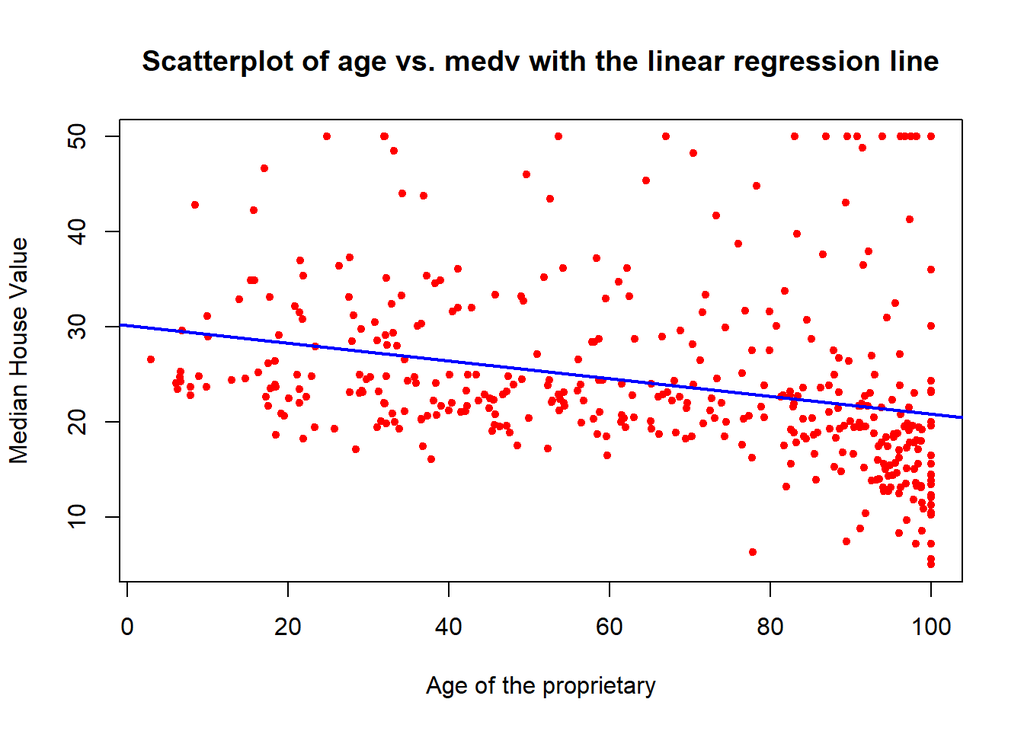

```r
plot(training_data$age, training_data$medv,
     xlab = "Age of the proprietary",
     ylab = "Median House Value",
     col = "red",
     main = "Scatterplot of age vs. medv with the linear regression line",
     pch = 20)
abline(model_age, col = "blue", lwd="2")
```

As infer above, there is a small correlation but the variability of the data is important.

### 5) Train a regression model using both lstat and age as predictors of median house value.

Now, we are going to use lstat and age as features to predict the medv target In the previous practical work, we check for linearity between lstat and medv and we come to the conclusion that we need to use a logarithm scale to get a stronger linear relationship:

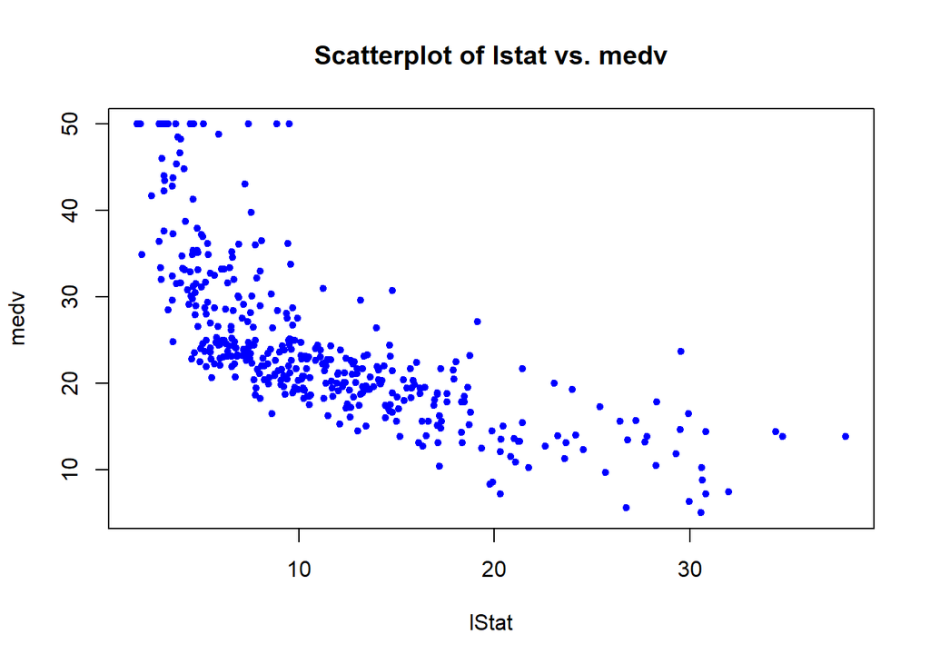

```r
plot(training_data$lstat, training_data$medv,
     xlab="lStat", ylab="medv",
     main="Scatterplot of lstat vs. medv",
     col="blue", type="p",pch = 20)
```

```r
print(cor(training_data$lstat, training_data$medv))
```

```
## [1] -0.7085914
```

```r
print(cor(log(training_data$lstat), training_data$medv))
```

```
## [1] -0.7961729
```

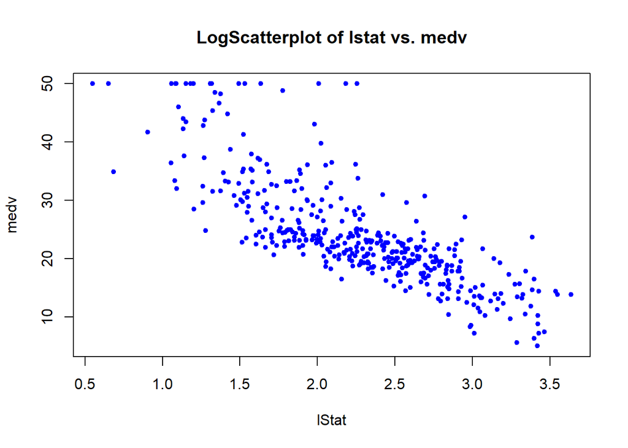

```r
plot(log(training_data$lstat), training_data$medv,
     xlab="lStat", ylab="medv",
     main="LogScatterplot of lstat vs. medv",
     col="blue", type="p",pch = 20)
```

Correlation coefficient before the log transformation between lstat and medv = -0.7085914  
Correlation coefficient after the log transformation between lstat and medv = -0.7961729

**Note:** We can’t do the same transformation for the age predictor because the weak linearship relation comes from the data variability

```r
model_age_lstat = lm(medv ~ age+log(lstat), data=training_data)
model_age_lstat
```

```
##
## Call:
## lm(formula = medv ~ age + log(lstat), data = training_data)
##
## Coefficients:
## (Intercept)          age   log(lstat)
##    51.88940      0.07636    -14.45560
```

### 6) Summary of the model

```r
# Print the summary of the obtained regression model :
summary(model_age_lstat)
```

```
##
## Call:
## lm(formula = medv ~ age + log(lstat), data = training_data)
##
## Residuals:
##      Min       1Q   Median       3Q      Max
## -13.5184  -3.4146  -0.8831   2.7192  23.0644
##
## Coefficients:
##              Estimate Std. Error t value Pr(>|t|)
## (Intercept)  51.88940    1.03417  50.175  < 2e-16 ***
## age           0.07636    0.01109   6.886 2.22e-11 ***
## log(lstat)  -14.45560    0.53907 -26.816  < 2e-16 ***
## ---
## Signif. codes:  0 '***' 0.001 '**' 0.01 '*' 0.05 '.' 0.1 ' ' 1
##
## Residual standard error: 5.312 on 401 degrees of freedom
## Multiple R-squared:  0.6726, Adjusted R-squared:  0.671
## F-statistic: 411.9 on 2 and 401 DF,  p-value: < 2.2e-16
```

### 7) Is the model as a whole significant?

There are two parameters to take into account for the whole significance:  
- P-value for the entire model compute with the Fisher test performed by R We found a p-value < 2.2e-16,  
So p-value < 0.05 => Since the p-value is less than the significance level (5%), we can conclude that our regression model fits the data better than the intercept-only model. So there is a significant relationship between the predictors (house owner age and percentage of households with low socioeconomic income) and the response (median house value)  
- F-statistic: The F value should always be used along with the p value in deciding whether your results are significant enough to reject the null hypothesis. Let’s calculate the F Critical Value

```r
qf(p=.05, df1=2, df2=401)
```

```
## [1] 0.05129986
```

```r
# where :
#p: The significance level to use
#df1: The numerator degrees of freedom
#df2: The denominator degrees of freedom
```

So F-statistic = 411.9 > F critical value 0.0512, so that’s confirming the p-value assumption

Thus, we can say that the model as a whole significant

Adjusted r-squared : closer to 1 : high proportion are explain by the input, 67,1% of variability is explained

### 8) Predictors significant

The predictors are both significant.

### 9) Model with all variables of the Boston dataset

```r
model_all_variables = lm(medv~., data=training_data)
model_all_variables
```

```
##
## Call:
## lm(formula = medv ~ ., data = training_data)
##
## Coefficients:
## (Intercept)         crim           zn        indus         chas          nox
##   30.077167    -0.202135     0.044128     0.052674     1.884743   -14.928149
##          rm          age          dis          rad          tax      ptratio
##    4.760387     0.002887    -1.300253     0.461662    -0.015543    -0.811632
##       black        lstat
##   -0.001972    -0.532273
```

### 10) Model with all variables (but log(lstat)) of the Boston dataset

```r
model_all_variables_log_lstat = lm(medv~.-lstat+log(lstat), data=training_data)
model_all_variables_log_lstat
```

```
##
## Call:
## lm(formula = medv ~ . - lstat + log(lstat), data = training_data)
##
## Coefficients:
## (Intercept)         crim           zn        indus         chas          nox
##   50.390675    -0.189244     0.025956     0.031066     1.685290   -13.937926
##          rm          age          dis          rad          tax      ptratio
##    3.188789     0.031168    -1.110556     0.397513    -0.014665    -0.737236
##       black   log(lstat)
##   -0.002038    -8.982855
```

### 11) Did $R^2$ improve ?

```r
summary(model_all_variables)$r.squared
```

```
## [1] 0.7337556
```

```r
summary(model_all_variables_log_lstat)$r.squared
```

```
## [1] 0.7854591
```

The $R^2$ squared improved a lot when we use log(stat) instead of stat

### 12) To see if there is correlated variables print the correlation matrix

```r
round(cor(training_data),2)
```

```
##          crim    zn indus  chas   nox    rm   age   dis   rad   tax ptratio
## crim     1.00 -0.17  0.37  0.00  0.40 -0.18  0.31 -0.34  0.65  0.60    0.22
## zn      -0.17  1.00 -0.51 -0.08 -0.49  0.31 -0.56  0.64 -0.24 -0.23   -0.33
## indus    0.37 -0.51  1.00  0.15  0.75 -0.40  0.62 -0.68  0.47  0.60    0.24
## chas     0.00 -0.08  0.15  1.00  0.17  0.08  0.14 -0.16  0.12  0.08   -0.07
## nox      0.40 -0.49  0.75  0.17  1.00 -0.32  0.72 -0.75  0.55  0.62    0.04
## rm      -0.18  0.31 -0.40  0.08 -0.32  1.00 -0.24  0.17 -0.22 -0.31   -0.36
## age      0.31 -0.56  0.62  0.14  0.72 -0.24  1.00 -0.73  0.40  0.45    0.17
## dis     -0.34  0.64 -0.68 -0.16 -0.75  0.17 -0.73  1.00 -0.43 -0.46   -0.11
## rad      0.65 -0.24  0.47  0.12  0.55 -0.22  0.40 -0.43  1.00  0.88    0.34
## tax      0.60 -0.23  0.60  0.08  0.62 -0.31  0.45 -0.46  0.88  1.00    0.31
## ptratio  0.22 -0.33  0.24 -0.07  0.04 -0.36  0.17 -0.11  0.34  0.31    1.00
## black   -0.04  0.13 -0.27 -0.05 -0.34  0.20 -0.21  0.20 -0.05 -0.15    0.08
## lstat    0.41 -0.39  0.56 -0.01  0.54 -0.64  0.58 -0.43  0.39  0.44    0.30
## medv    -0.30  0.31 -0.39  0.14 -0.32  0.75 -0.29  0.13 -0.23 -0.34   -0.44
##         black lstat  medv
## crim    -0.04  0.41 -0.30
## zn       0.13 -0.39  0.31
## indus   -0.27  0.56 -0.39
## chas    -0.05 -0.01  0.14
## nox     -0.34  0.54 -0.32
## rm       0.20 -0.64  0.75
## age     -0.21  0.58 -0.29
## dis      0.20 -0.43  0.13
## rad     -0.05  0.39 -0.23
## tax     -0.15  0.44 -0.34
## ptratio  0.08  0.30 -0.44
## black    1.00 -0.16  0.14
## lstat   -0.16  1.00 -0.71
## medv     0.14 -0.71  1.00
```

### 13) Visualize the correlations

```r
#install.packages("corrplot")
```

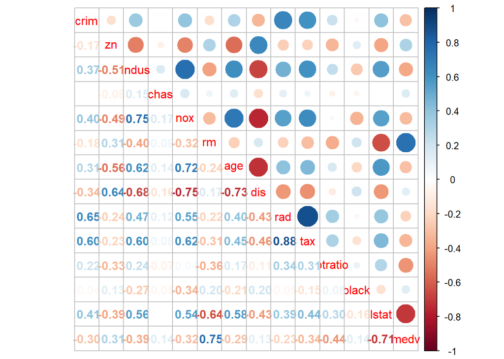

```r
library(corrplot)
M = cor(training_data)
corrplot.mixed(M)
```

### 14) Correlation between tax and rad

corr = 0.88 high, near 1  
If the result is different that comes from I took the 80% first values (404 values) instead of the 400 first ones

Tax and rad are very positively correlated

### 15) Run the model again without tax. What happens to the R2 and for the F-statistic?

```r
model_without_tax = lm(medv~.-(tax+lstat)+log(lstat), data=training_data)
summary(model_all_variables_log_lstat)$r.squared
```

```
## [1] 0.7854591
```

```r
summary(model_without_tax)$r.squared
```

```
## [1] 0.7781724
```

```r
summary(model_all_variables_log_lstat)$fstatistic["value"]
```

```
##    value
## 109.8335
```

```r
summary(model_without_tax)$fstatistic["value"]
```

```
##    value
## 114.3025
```

F-statistic = 109.8335  
F-statistic without tax = 114.3025

$R^2$ = 0.7854591  
$R^2$ without tax = 0.7781724

R^2 decreased because we deleted one of the variable. However, the F-statistic increased, which means the p-values gets lower and thus the model is more significant without tax.

### 16) MSE

```r
y = testing_data$medv

# Compute the predicted value for this y (y hat)
y_hat = predict(model_without_tax, data.frame(testing_data))

# Now we have both y and y_hat for our testing data.
# let's find the mean square error
error = y-y_hat
error_squared = error^2
MSE = mean(error_squared)
MSE
```

```
## [1] 20.07063
```

## ANOVA

### 17) In the Boston data set there is a categorical variable chas which corresponds to Charles River (= 1 if a suburb bounds the river; 0 otherwise). Use command str() to see how this variable is present in the dataset. How many of the suburbs in this data set bound the Charles river?

```r
str(Boston$chas)
```

```
##  int [1:506] 0 0 0 0 0 0 0 0 0 0 ...
```

```r
table(Boston$chas)
```

```
##
##   0   1
## 471  35
```

```r
sum(Boston$chas)
```

```
## [1] 35
```

There are 35 suburbs in this data set bound the Charles river.

### 18) Do we observe some difference between the median value of houses with respect to the neighborhood to Charles River?

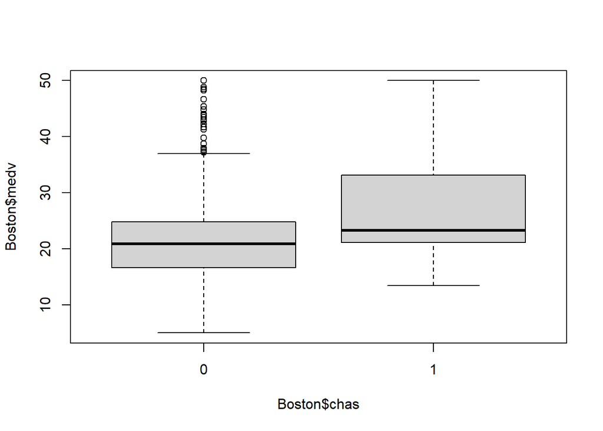

```r
boxplot(Boston$medv ~ Boston$chas)
```

Observation :  
The house near the river have a higher median value but the not really significant (and also a much higher quartiles 1 and 3, minimum and maximum).

### 19) Calculate $μ_i$ and $μ_j$

```r
aggregate(Boston$medv, list(Boston$chas),FUN=mean)
```

```
##   Group.1        x
## 1       0 22.09384
## 2       1 28.44000
```

We observe a much higher mean price if near river (28,44 vs 22.09).

### 20) Apply an ANOVA test of medv whith respect to chas (use the function aov())

```r
anova = aov(medv~chas, data=Boston)
anova
```

```
## Call:
##    aov(formula = medv ~ chas, data = Boston)
##
## Terms:
##                     chas Residuals
## Sum of Squares   1312.08  41404.22
## Deg. of Freedom        1       504
##
## Residual standard error: 9.063731
## Estimated effects may be unbalanced
```

```r
summary(anova)
```

```
##              Df Sum Sq Mean Sq F value   Pr(>F)
## chas          1   1312  1312.1   15.97 7.39e-05 ***
## Residuals   504  41404    82.2
## ---
## Signif. codes:  0 '***' 0.001 '**' 0.01 '*' 0.05 '.' 0.1 ' ' 1
```

p = 7.39e-05 < 0.05 (threshold of significance)  
We can reject the null hypothesis and conclude that there is a significative difference of price depending of the proximity of the river.

## Qualitative predictors

### 21) Fit a new model where the predictors are the Charles River and the Crime Rate. Interpret the coefficients of this model and conclude if the presence of the river adds a valuable information for explaining the house price.

```r
model_crim_chas = lm(medv~crim+chas, data=training_data)
model_crim = lm(medv~crim, data=training_data)
model_crim_chas
```

```
##
## Call:
## lm(formula = medv ~ crim + chas, data = training_data)
##
## Coefficients:
## (Intercept)         crim         chas
##     24.6234      -0.4434       4.6375
```

```r
model_crim
```

```
##
## Call:
## lm(formula = medv ~ crim, data = training_data)
##
## Coefficients:
## (Intercept)         crim
##      25.026       -0.444
```

```r
summary(model_crim)$fstatistic["value"]
```

```
##    value
## 39.22707
```

```r
summary(model_crim_chas)$fstatistic["value"]
```

```
##    value
## 24.47648
```

```r
summary(model_crim)$r.squared
```

```
## [1] 0.08890449
```

```r
summary(model_crim_chas)$r.squared
```

```
## [1] 0.1087957
```

```r
summary(model_crim)
```

```
##
## Call:
## lm(formula = medv ~ crim, data = training_data)
##
## Residuals:
##     Min      1Q  Median      3Q     Max
## -14.323  -5.681  -2.276   3.443  29.073
##
## Coefficients:
##             Estimate Std. Error t value Pr(>|t|)
## (Intercept) 25.02645    0.46081  54.309  < 2e-16 ***
## crim        -0.44402    0.07089  -6.263 9.71e-10 ***
## ---
## Signif. codes:  0 '***' 0.001 '**' 0.01 '*' 0.05 '.' 0.1 ' ' 1
##
## Residual standard error: 8.851 on 402 degrees of freedom
## Multiple R-squared:  0.0889, Adjusted R-squared:  0.08664
## F-statistic: 39.23 on 1 and 402 DF,  p-value: 9.706e-10
```

```r
summary(model_crim_chas)
```

```
##
## Call:
## lm(formula = medv ~ crim + chas, data = training_data)
##
## Residuals:
##     Min      1Q  Median      3Q     Max
## -14.389  -5.822  -2.183   3.649  29.470
##
## Coefficients:
##             Estimate Std. Error t value Pr(>|t|)
## (Intercept)  24.6234     0.4758  51.752  < 2e-16 ***
## crim         -0.4434     0.0702  -6.315 7.17e-10 ***
## chas          4.6376     1.5501   2.992  0.00295 **
## ---
## Signif. codes:  0 '***' 0.001 '**' 0.01 '*' 0.05 '.' 0.1 ' ' 1
##
## Residual standard error: 8.765 on 401 degrees of freedom
## Multiple R-squared:  0.1088, Adjusted R-squared:  0.1044
## F-statistic: 24.48 on 2 and 401 DF,  p-value: 9.342e-11
```

```r
print(cor(training_data$chas, training_data$medv))
```

```
## [1] 0.1419852
```

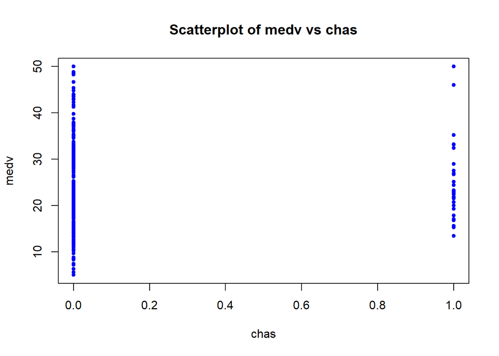

```r
plot(training_data$chas, training_data$medv,
     xlab="chas", ylab="medv", main = "Scatterplot of medv vs chas",
     col="blue", type="p",pch = 20)
```

```r
print(cor(training_data$crim, training_data$medv))
```

```
## [1] -0.2981686
```

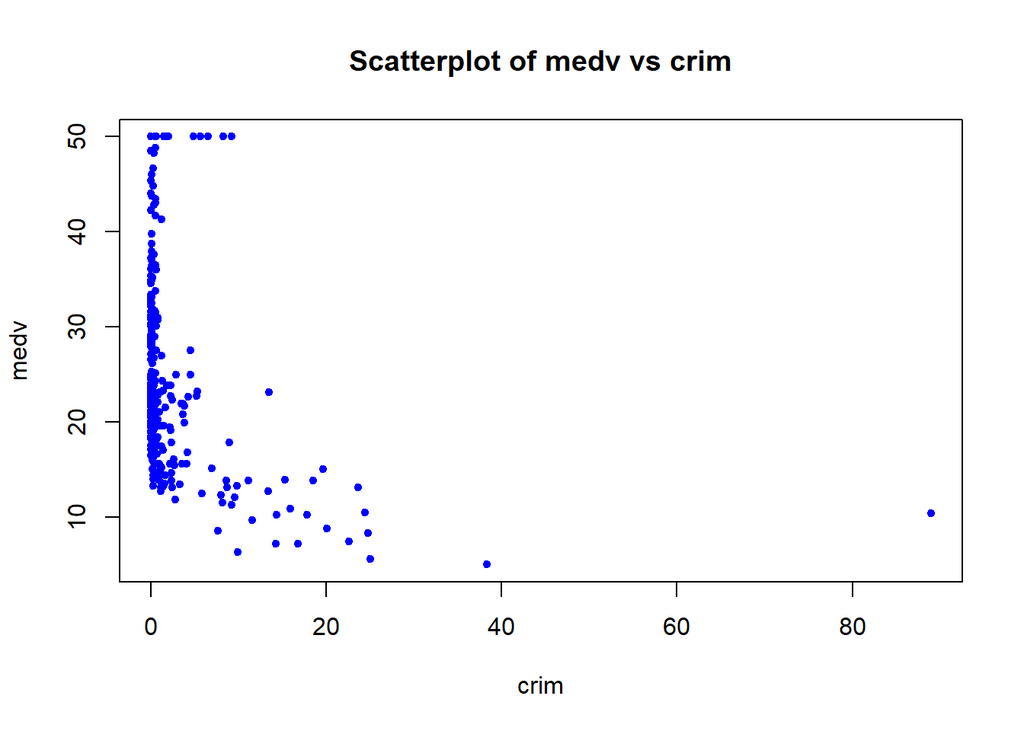

```r
plot(training_data$crim, training_data$medv,
     xlab="crim", ylab="medv", main = "Scatterplot of medv vs crim",
     col="blue", type="p",pch = 20)
```

### 22) Is chas significant as well in the presence of more predictors?

```r
model_all = lm(medv~., data=training_data)
model_all_without_chas = lm(medv~.-chas, data=training_data)
summary(model_all)
```

```
##
## Call:
## lm(formula = medv ~ ., data = training_data)
##
## Residuals:
##      Min       1Q   Median       3Q      Max
## -19.9717  -2.7981  -0.6206   1.5642  25.3066
##
## Coefficients:
##               Estimate Std. Error t value Pr(>|t|)
## (Intercept)  30.077167   6.196821   4.854 1.76e-06 ***
## crim         -0.202135   0.053695  -3.764 0.000193 ***
## zn            0.044128   0.014257   3.095 0.002109 **
## indus         0.052674   0.066204   0.796 0.426729
## chas          1.884743   0.898988   2.097 0.036680 *
## nox         -14.928149   4.604692  -3.242 0.001289 **
## rm            4.760387   0.486625   9.782  < 2e-16 ***
## age           0.002887   0.014474   0.199 0.841983
## dis          -1.300253   0.213913  -6.078 2.89e-09 ***
## rad           0.461662   0.087944   5.249 2.51e-07 ***
## tax          -0.015543   0.004493  -3.460 0.000601 ***
## ptratio      -0.811632   0.141526  -5.735 1.96e-08 ***
## black        -0.001972   0.006597  -0.299 0.765179
## lstat        -0.532273   0.059777  -8.904  < 2e-16 ***
## ---
## Signif. codes:  0 '***' 0.001 '**' 0.01 '*' 0.05 '.' 0.1 ' ' 1
##
## Residual standard error: 4.858 on 390 degrees of freedom
## Multiple R-squared:  0.7338, Adjusted R-squared:  0.7249
## F-statistic: 82.68 on 13 and 390 DF,  p-value: < 2.2e-16
```

```r
summary(model_all_without_chas)
```

```
##
## Call:
## lm(formula = medv ~ . - chas, data = training_data)
##
## Residuals:
##      Min       1Q   Median       3Q      Max
## -18.7820  -2.6875  -0.6299   1.8844  24.8878
##
## Coefficients:
##               Estimate Std. Error t value Pr(>|t|)
## (Intercept)  30.188516   6.223440   4.851 1.78e-06 ***
## crim         -0.213786   0.053638  -3.986 8.03e-05 ***
## zn            0.044258   0.014319   3.091 0.002138 **
## indus         0.069146   0.066021   1.047 0.295590
## nox         -14.738701   4.623752  -3.188 0.001550 **
## rm            4.831015   0.487561   9.909  < 2e-16 ***
## age           0.004073   0.014525   0.280 0.779311
## dis          -1.301355   0.214840  -6.057 3.25e-09 ***
## rad           0.490549   0.087234   5.623 3.57e-08 ***
## tax          -0.016520   0.004488  -3.681 0.000265 ***
## ptratio      -0.834421   0.141719  -5.888 8.43e-09 ***
## black        -0.002205   0.006624  -0.333 0.739450
## lstat        -0.537202   0.059990  -8.955  < 2e-16 ***
## ---
## Signif. codes:  0 '***' 0.001 '**' 0.01 '*' 0.05 '.' 0.1 ' ' 1
##
## Residual standard error: 4.879 on 391 degrees of freedom
## Multiple R-squared:  0.7308, Adjusted R-squared:  0.7225
## F-statistic: 88.43 on 12 and 391 DF,  p-value: < 2.2e-16
```

## Interaction terms

### 23) Fit a model with first order interaction term where predictors are lstat and age. Print its summary.

```r
model_interaction_terms = lm(medv~lstat:age, data=training_data)
summary(model_interaction_terms)
```

```
##
## Call:
## lm(formula = medv ~ lstat:age, data = training_data)
##
## Residuals:
##     Min      1Q  Median      3Q     Max
## -11.033  -4.785  -1.719   2.650  26.638
##
## Coefficients:
##               Estimate Std. Error t value Pr(>|t|)
## (Intercept) 30.5660871  0.5396910   56.64   <2e-16 ***
## lstat:age   -0.0075594  0.0004744  -15.94   <2e-16 ***
## ---
## Signif. codes:  0 '***' 0.001 '**' 0.01 '*' 0.05 '.' 0.1 ' ' 1
##
## Residual standard error: 7.259 on 402 degrees of freedom
## Multiple R-squared:  0.3871, Adjusted R-squared:  0.3856
## F-statistic: 253.9 on 1 and 402 DF,  p-value: < 2.2e-16
```

```r
model_age_lstat = lm(medv~lstat+age, data=training_data)
summary(model_age_lstat)
```

```
##
## Call:
## lm(formula = medv ~ lstat + age, data = training_data)
##
## Residuals:
##     Min      1Q  Median      3Q     Max
## -10.382  -4.389  -1.503   2.546  22.471
##
## Coefficients:
##             Estimate Std. Error t value Pr(>|t|)
## (Intercept) 33.08556    0.79234  41.757  < 2e-16 ***
## lstat       -1.09628    0.05729 -19.134  < 2e-16 ***
## age          0.05492    0.01346   4.082  5.4e-05 ***
## ---
## Signif. codes:  0 '***' 0.001 '**' 0.01 '*' 0.05 '.' 0.1 ' ' 1
##
## Residual standard error: 6.419 on 401 degrees of freedom
## Multiple R-squared:  0.522,  Adjusted R-squared:  0.5196
## F-statistic: 218.9 on 2 and 401 DF,  p-value: < 2.2e-16
```

### 24) Fit a model with all the first order interaction terms

```r
model_age_lstat = lm(medv~lstat*age, data=training_data)
summary(model_age_lstat)
```

```
##
## Call:
## lm(formula = medv ~ lstat * age, data = training_data)
##
## Residuals:
##     Min      1Q  Median      3Q     Max
## -10.161  -4.368  -1.535   2.356  28.741
##
## Coefficients:
##              Estimate Std. Error t value Pr(>|t|)
## (Intercept) 35.553896   1.592422  22.327  < 2e-16 ***
## lstat       -1.418663   0.189395  -7.491 4.43e-13 ***
## age          0.024003   0.021908   1.096    0.274
## lstat:age    0.003767   0.002110   1.785    0.075 .
## ---
## Signif. codes:  0 '***' 0.001 '**' 0.01 '*' 0.05 '.' 0.1 ' ' 1
##
## Residual standard error: 6.402 on 400 degrees of freedom
## Multiple R-squared:  0.5257, Adjusted R-squared:  0.5222
## F-statistic: 147.8 on 3 and 400 DF,  p-value: < 2.2e-16
```